# Prosper Loan Data Analysis with R

#### It would be a good idea to see what their credit is like. They could have been unemployed for any reason.

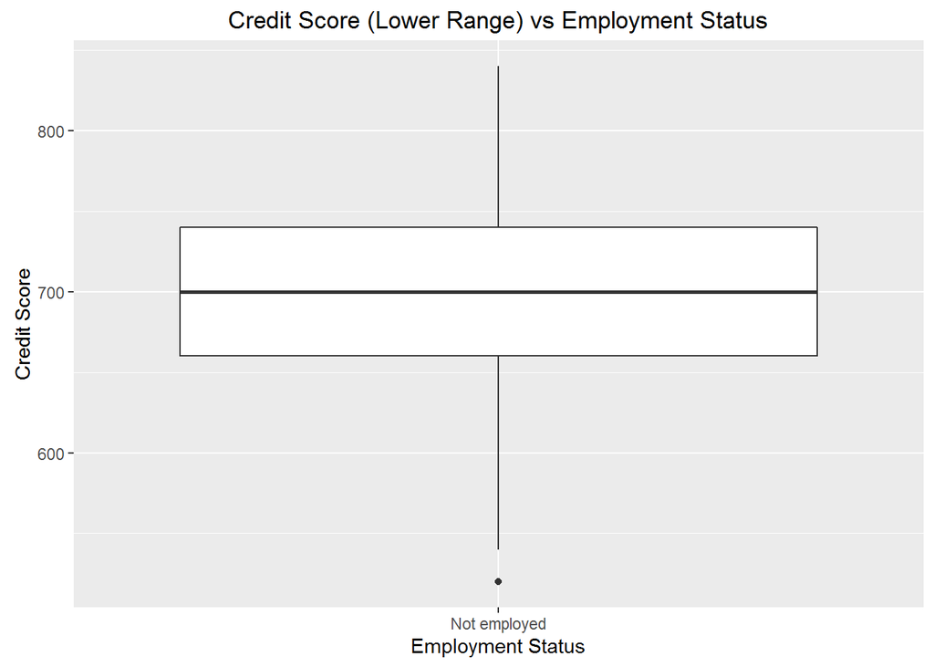

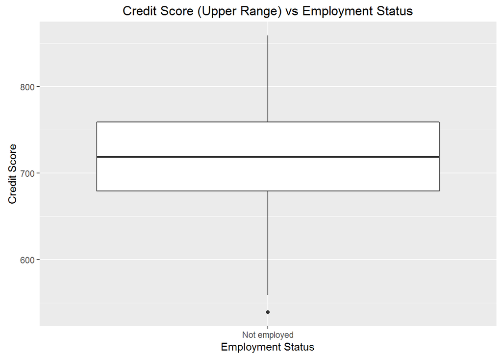

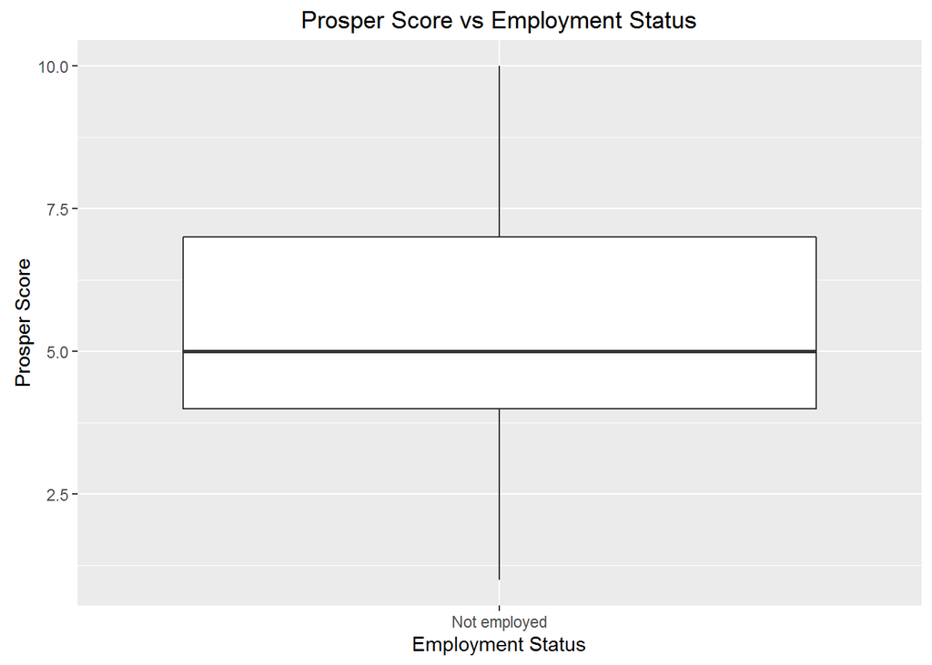

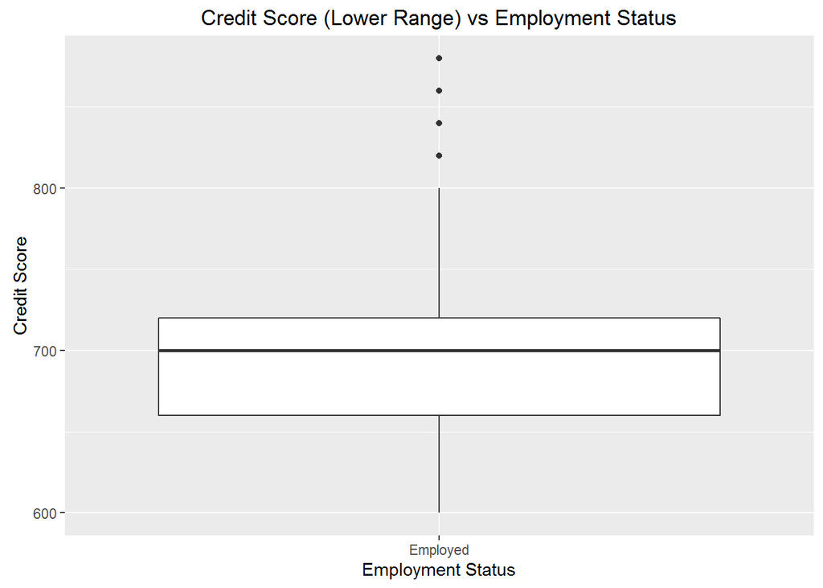

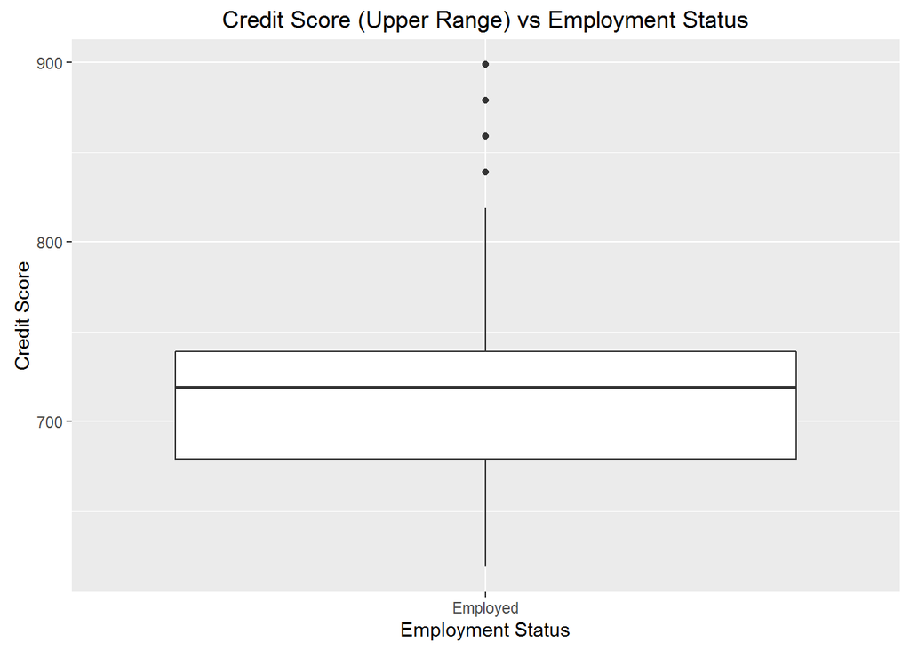

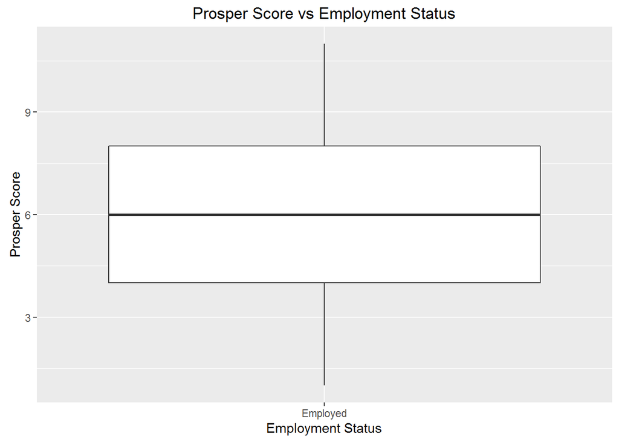

#### Does the credit score have an effect on the Prosper score?

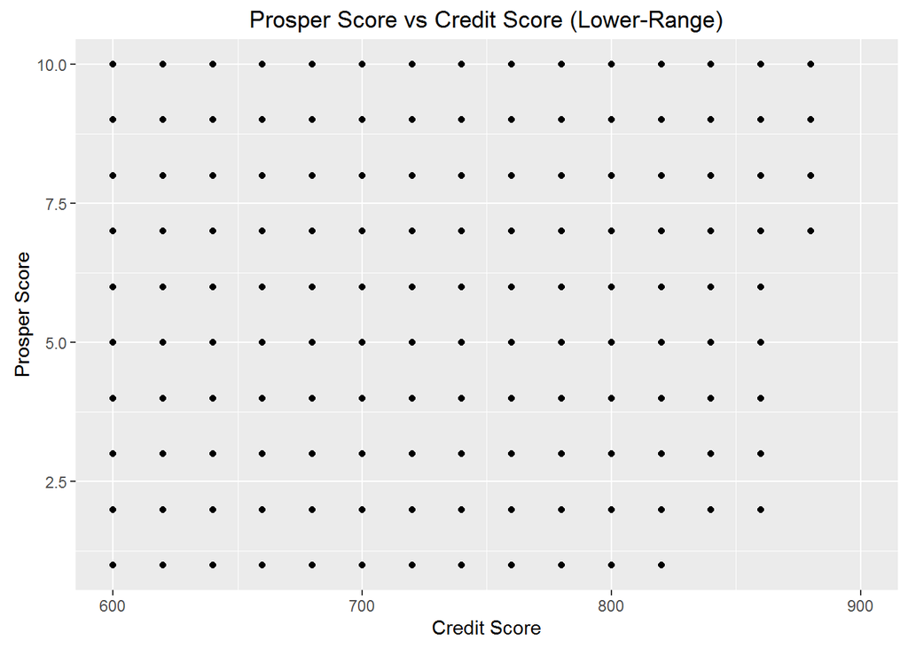

[figure not shown]

# Bivariate Analysis

### What was the strongest relationship you found?

#### It seems that higher income results in obtaining a higher Prosper score and having the option of higher loan amounts. Another fact that could support this is that those who reported to be unemployed had lesser loan amounts, even though they appeared to have higher credit scores (not Prosper scores). So the amount of income might be a strong relationship to risk assessment within the Prosper community.

# Multivariate Plots Section

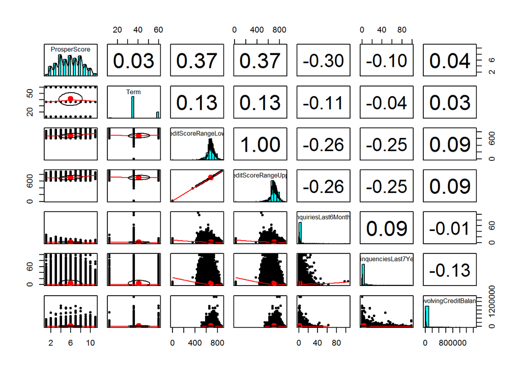

```
##        ProsperScore Term CreditScoreRangeLower CreditScoreRangeUpper
## 113932            6   60                   800                   819
## 113933            5   36                   700                   719
## 113934            8   36                   700                   719
## 113935            3   60                   700                   719
## 113936            5   60                   680                   699
## 113937            7   36                   680                   699
##        InquiriesLast6Months DelinquenciesLast7Years RevolvingCreditBalance
## 113932                    2                       0                    566
## 113933                    0                       7                   7714
## 113934                    1                       4                  15743
## 113935                    1                       0                  22147
## 113936                    1                       0                  11956
## 113937                    0                       3                   6166
```

```
##   ProsperScore Term CreditScoreRangeLower CreditScoreRangeUpper
## 1           NA   36                   640                   659
## 2            7   36                   680                   699
## 3           NA   36                   480                   499
## 4            9   36                   800                   819
## 5            4   36                   680                   699
## 6           10   60                   740                   759
##   InquiriesLast6Months DelinquenciesLast7Years RevolvingCreditBalance
## 1                    3                       4                      0
## 2                    3                       0                   3989
## 3                    0                       0                     NA
## 4                    0                      14                   1444
## 5                    1                       0                   6193
## 6                    0                       0                  62999
```

#### Individuals with a Prosper score between 1 and 3 mostly have less original loan amounts than those with a score between 4 and 10. The only significant advantage in having a Prosper score higher than 4, 5, and 6 is that those who are ‘not employed,’ or have an employment status of ‘other,’ receive higher original loan amounts.

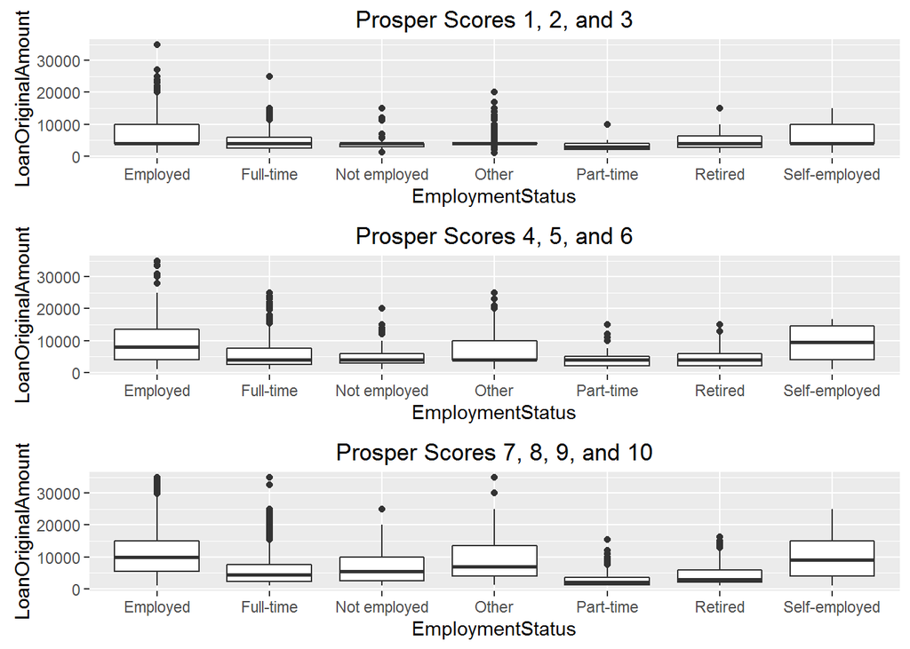

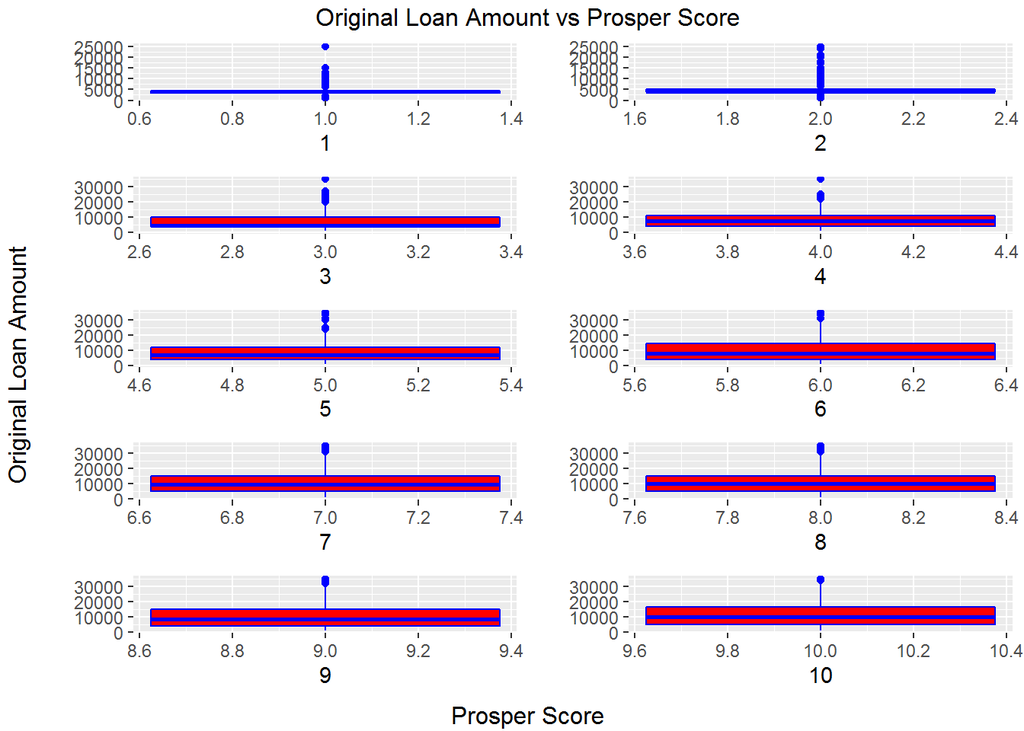

# Multivariate Analysis

### Talk about some of the relationships you observed in this part of the investigation. Were there features that strengthened each other in terms of looking at your feature(s) of interest?

#### The Prosper score seems to show a significant effect on the amount of loan granted when it is between 1 and 6, but it seems to have a stagnant effect on the loan amount when it is 6 or more. At which point, other matters show more of an effect, such as employment status.

### Were there any interesting or surprising interactions between features?

#### Self-employed individuals appear to be trusted just as much as the non-self-employed individuals. At first, one may assume that self-employed individuals could be seen as ones who face higher risks and might be judged to have less income security.

# Final Plots and Summary

### Plot One

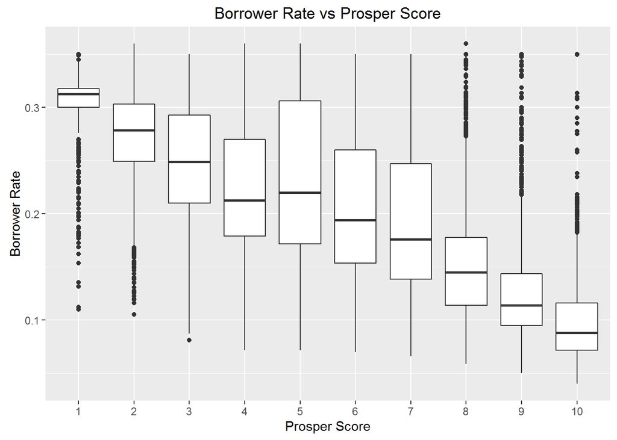

### Description One

#### The median, Q1, and Q3 of the borrower rate decreases as the Prosper score increases. The decrease in the median and Q3 of the borrower rate is discontinued for Prosper score 5 in this dataset, but it’s continued again from score 6 to 10. Other factors may have affected the borrower rate for those with a Prosper score of 5 in this dataset.

### Plot Two

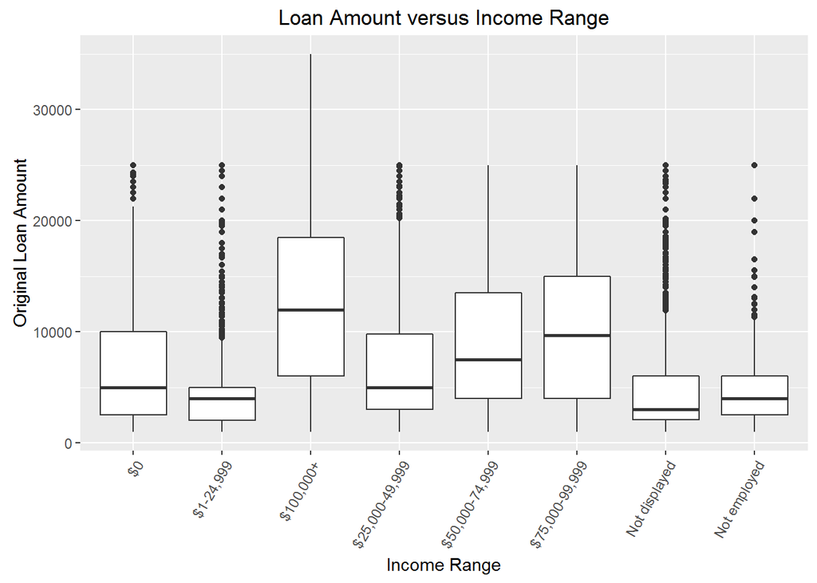

### Description Two

#### As the income range increases, so does the median loan amount, along with the first and third quartiles. This trend is most likely due to the availability of higher loan amounts with respect to higher income ranges.

#### The $0 plot appears similar to the $25,000-49,999 and may be used as a way to not provide income information. It could be that when the income information is not provided, the individual is assumed to have the same level of risk as someone who has an income range of $25,000-49,999.

### Plot Three

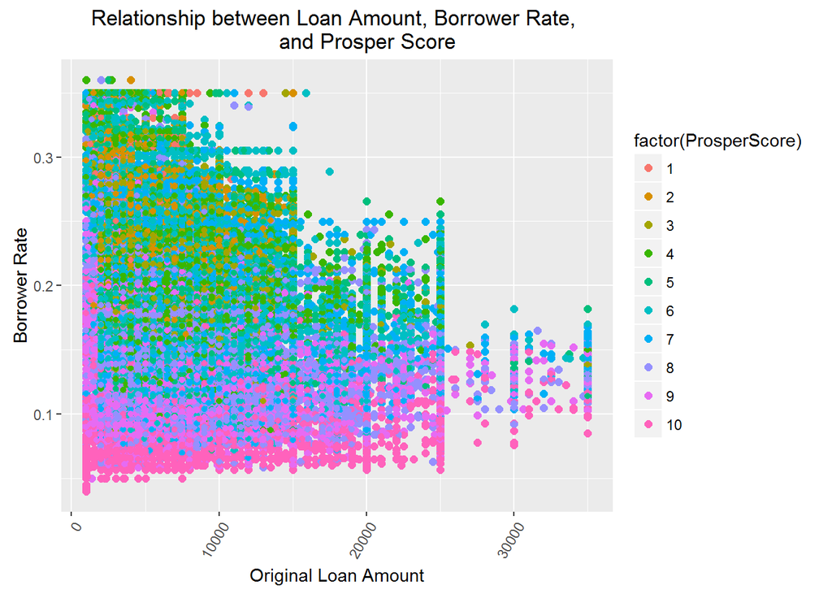

### Description Three

#### As apparent, the borrower rate decreases as the original loan amount increases. It’s also evident that those with the higher Prosper scores are mostly awarded low rates.

# Reflection